# Cluster Analysis - Part 3

WDI Indicators

Mohammadmahdi Faryabi - STD-ID: 93101951

2018-07-20 17:10:18

> با توجه به داده بانک جهانی به سوالات زیر پاسخ دهید. برای استفاده از داده از سه فایل زیر استفاده نمایید. داده نام کشورها: WDICountry داده نام سری های زمانی: WDISeries داده کل: WDIData در صورتی که داده را در اختیار ندارید می توانید از بسته WDI استفاده نموده و داده های مورد نظر را استخراج نمایید.

> gathering required data and loading required packages…

```r
library(WDI)
library(dplyr)
```

```r
library(readr)
library(highcharter)
library(tidyr)

country_series <- read_csv('../../WDI_csv/WDICountry-Series.csv')
country <- read_csv('../../WDI_csv/WDICountry.csv')
data <- read_csv('../../WDI_csv/WDIData.csv')
footnote <- read_csv('../../WDI_csv/WDIFootNote.csv')
series_time <- read_csv('../../WDI_csv/WDISeries-Time.csv')
series <- read_csv('../../WDI_csv/WDISeries.csv')
compare_iran_with_others <- function (indicator_code, indicator_name) {
  data %>% filter(`Indicator Code` == indicator_code) %>%
    gather(key = 'year', value = 'lexp', `1960`:`2016`) %>%
    select(`Country Name`, `Country Code`, year, lexp) %>% .[complete.cases(.),] -> all_country_data


  iran_data <- all_country_data %>% filter(`Country Code` == 'IRN')

  hcboxplot(x = all_country_data$lexp, var = all_country_data$year, outliers = FALSE) %>% hc_chart(type = "column") %>%
    hc_add_series(type = 'line', iran_data, color = 'red', hcaes(x = year, y = lexp)) %>%
    hc_yAxis(title = list(text = indicator_name)) %>%
    hc_xAxis(title = list(text = 'Year'))
}

normalize <- function(column) {
  result <- (column - mean(column, na.rm = TRUE)) / sd(column, na.rm = TRUE)
  return(result)
}
```

۸. با استفاده از داده روشی برای پیش بینی رشد اقتصادی ایران در سال آینده ارائه دهید.

> i’ve used H2O deep learing model and given all iran previous data to it as input. then I’ve estimated the data for the upcomming year using it.

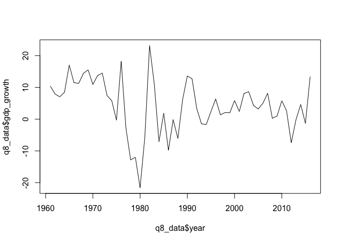

```r
################################################################################
#### Q8

data %>% filter(`Indicator Code` == 'NY.GDP.MKTP.KD.ZG', `Country Code` == 'IRN') %>%
  gather(key = 'year', value = 'gdp_growth', `1960`:`2016`) %>%
  select(year, gdp_growth) %>% .[complete.cases(.),] -> q8_data

q8_data$year <- as.integer(q8_data$year)

plot(type = 'l', q8_data$year, q8_data$gdp_growth)
```

```r
library(h2o)
h2o.init()
```

[output not shown]

```r
q8_data_h2o <- as.h2o(q8_data)
q8_model <- h2o.deeplearning(y = 'gdp_growth', x = colnames(q8_data_h2o),  q8_data_h2o)
q8_prediction <- h2o.predict(q8_model, as.h2o(data.frame(year = 2017)))
```

```r
q8_data %>% mutate(type = 'observation') %>% rbind(
  q8_data %>% filter(year == 2016) %>% mutate(type = 'predict') %>%
    rbind(cbind(
      data.frame(year = 2017, type = 'predict'),
      q8_prediction %>% as.data.frame %>% dplyr::rename(gdp_growth = 'predict')
    )) %>% select(year, gdp_growth, type)
  ) %>% hchart(type = 'line', hcaes(x = year, y = gdp_growth, group = type))
```

[interactive chart not shown]

۹. سوالهای ۵ تا ۷ را ابتدا برای ۲۰ شاخص سلامت سپس بر حسب ۲۰ شاخص آموزشی تکرار کنید.

```r
################################################################################
#### Q9-5-Health

compare_iran_with_others('SH.DYN.MORT', 'Mortality rate, under-5 (per 1,000 live births)')
```

[interactive chart not shown]

```r
compare_iran_with_others('SH.DYN.NCOM.ZS', 'Mortality from CVD, cancer, diabetes or CRD between exact ages 30 and 70 (%)')
```

[interactive chart not shown]

```r
compare_iran_with_others('SH.MED.BEDS.ZS', 'Hospital beds (per 1,000 people)')
```

[interactive chart not shown]

```r
compare_iran_with_others('SH.STA.ANVC.ZS', 'Pregnant women receiving prenatal care (%)')
```

[interactive chart not shown]

```r
compare_iran_with_others('SH.STA.SUIC.P5', 'Suicide mortality rate (per 100,000 population)')
```

[interactive chart not shown]

```r
compare_iran_with_others('SH.STA.TRAF.P5', 'Mortality caused by road traffic injury (per 100,000 people)')
```

[interactive chart not shown]

```r
compare_iran_with_others('SP.DYN.LE00.FE.IN', 'Life expectancy at birth, female (years)')
```

[interactive chart not shown]

```r
compare_iran_with_others('SP.DYN.LE00.MA.IN', 'Life expectancy at birth, male (years)')
```

[interactive chart not shown]

```r
compare_iran_with_others('SP.DYN.TO65.FE.ZS', 'Survival to age 65, female (% of cohort)')
```

[interactive chart not shown]

```r
compare_iran_with_others('SP.DYN.TO65.MA.ZS', 'Survival to age 65, male (% of cohort)')
```

[interactive chart not shown]

```r
compare_iran_with_others('SP.POP.0014.TO.ZS', 'Population ages 0-14 (% of total)')
```

[interactive chart not shown]

```r
compare_iran_with_others('SP.POP.1564.TO.ZS', 'Population ages 15-64 (% of total)')
```

[interactive chart not shown]

```r
compare_iran_with_others('SP.POP.65UP.TO.ZS', 'Population ages 65 and above (% of total)')
```

[interactive chart not shown]

```r
compare_iran_with_others('SH.IMM.IDPT', 'Immunization, DPT (% of children ages 12-23 months)')
```

[interactive chart not shown]

```r
compare_iran_with_others('SH.IMM.MEAS', 'Immunization, measles (% of children ages 12-23 months)')
```

[interactive chart not shown]

```r
compare_iran_with_others('SH.XPD.CHEX.GD.ZS', 'Current health expenditure (% of GDP)')
```

[interactive chart not shown]

```r
compare_iran_with_others('SH.MMR.DTHS', 'Number of maternal deaths')
```

[interactive chart not shown]

```r
compare_iran_with_others('SH.H2O.BASW.ZS', 'People using at least basic drinking water services (% of population)')
```

[interactive chart not shown]

```r
compare_iran_with_others('SH.H2O.SMDW.ZS', 'People using safely managed drinking water services (% of population)')
```

[interactive chart not shown]

```r
compare_iran_with_others('SH.HIV.1524.FE.ZS', 'Prevalence of HIV, female (% ages 15-24)')
```

[interactive chart not shown]

```r
compare_iran_with_others('SH.HIV.1524.MA.ZS', 'Prevalence of HIV, male (% ages 15-24)')
```

[interactive chart not shown]

```r
################################################################################
#### Q9-5-Education

compare_iran_with_others('SE.ADT.1524.LT.FE.ZS', 'Literacy rate, youth female (% of females ages 15-24)')
```

[interactive chart not shown]

```r
compare_iran_with_others('SE.ADT.1524.LT.MA.ZS', 'Literacy rate, youth male (% of males ages 15-24)')
```

[interactive chart not shown]

```r
compare_iran_with_others('SE.ADT.LITR.FE.ZS', 'Literacy rate, adult female (% of females ages 15 and above)')
```

[interactive chart not shown]

```r
compare_iran_with_others('SE.ADT.LITR.MA.ZS', 'Literacy rate, adult male (% of males ages 15 and above)')
```

[interactive chart not shown]

```r
compare_iran_with_others('SE.COM.DURS', 'Compulsory education, duration (years)')
```

[interactive chart not shown]

```r
compare_iran_with_others('SE.PRM.NENR', 'School enrollment, primary (% net)')
```

[interactive chart not shown]

```r
compare_iran_with_others('SE.XPD.PRIM.PC.ZS', 'Government expenditure per student, primary (% of GDP per capita)')
```

[interactive chart not shown]

```r
compare_iran_with_others('SE.XPD.SECO.PC.ZS', 'Government expenditure per student, secondary (% of GDP per capita)')
```

[interactive chart not shown]

```r
compare_iran_with_others('SE.XPD.TERT.PC.ZS', 'Government expenditure per student, tertiary (% of GDP per capita)')
```

[interactive chart not shown]

```r
compare_iran_with_others('SE.XPD.PRIM.ZS', 'Expenditure on primary education (% of government expenditure on education)')
```

[interactive chart not shown]

```r
compare_iran_with_others('SE.XPD.SECO.ZS', 'Expenditure on secondary education (% of government expenditure on education)')
```

[interactive chart not shown]

```r
compare_iran_with_others('SE.XPD.TERT.ZS', 'Expenditure on tertiary education (% of government expenditure on education)')
```

[interactive chart not shown]

```r
compare_iran_with_others('IP.JRN.ARTC.SC', 'Scientific and technical journal articles')
```

[interactive chart not shown]

```r
compare_iran_with_others('GB.XPD.RSDV.GD.ZS', 'Research and development expenditure (% of GDP)')
```

[interactive chart not shown]

```r
compare_iran_with_others('SE.PRE.ENRL.TC.ZS', 'Pupil-teacher ratio, preprimary')
```

[interactive chart not shown]

```r
compare_iran_with_others('SE.PRE.ENRR.FE', 'School enrollment, preprimary, female (% gross)')
```

[interactive chart not shown]

```r
compare_iran_with_others('SE.PRE.ENRR.MA', 'School enrollment, preprimary, male (% gross)')
```

[interactive chart not shown]

```r
compare_iran_with_others('SE.PRM.AGES', 'Primary school starting age (years)')
```

[interactive chart not shown]

```r
compare_iran_with_others('SE.PRM.CMPT.FE.ZS', 'Primary completion rate, female (% of relevant age group)')
```

[interactive chart not shown]

```r
compare_iran_with_others('SE.PRM.CMPT.MA.ZS', 'Primary completion rate, male (% of relevant age group)')
```

[interactive chart not shown]

```r
################################################################################
#### Q9-6-Health

q96H_series <- c('SH.DYN.MORT', 'SH.DYN.NCOM.ZS', 'SH.MED.BEDS.ZS', 'SH.STA.ANVC.ZS',
                 'SH.STA.SUIC.P5', 'SH.STA.TRAF.P5', 'SP.DYN.LE00.FE.IN', 'SP.DYN.LE00.MA.IN',
                 'SP.DYN.TO65.FE.ZS', 'SP.DYN.TO65.MA.ZS', 'SP.POP.0014.TO.ZS', 'SP.POP.1564.TO.ZS',
                 'SP.POP.65UP.TO.ZS', 'SH.IMM.IDPT', 'SH.IMM.MEAS', 'SH.XPD.CHEX.GD.ZS', 'SH.MMR.DTHS',
                 'SH.H2O.BASW.ZS', 'SH.H2O.SMDW.ZS', 'SH.HIV.1524.FE.ZS', 'SH.HIV.1524.MA.ZS')

data %>% select(-X63) %>% filter(`Indicator Code` %in% q96H_series) %>%
  gather(key = 'year', value = 'value', `1960`:`2017`) %>%
  dplyr::group_by(`Indicator Code`) %>% dplyr::mutate(value = normalize(value)) %>%
  ungroup %>% dplyr::group_by(`Country Name`, `Country Code`, `Indicator Code`) %>%
  dplyr::summarise(mean_value = mean(value, na.rm = TRUE)) -> q96H_data

q96H_data %>% spread(key = `Indicator Code`, value = mean_value) -> q96H_data

q96H_data %>% ungroup -> q96H_data

# filling NAs with mean of the column

for (i in 1:ncol(q96H_data)) {
  if ((q96H_data[which(is.na(q96H_data[i])),i] %>% nrow) > 0) {
    q96H_data[which(is.na(q96H_data[i])),i] <- q96H_data[i] %>% na.omit %>% unlist %>% mean
  }
}

q96H_data %>% select(SH.DYN.MORT:SP.POP.65UP.TO.ZS) %>% kmeans(centers = 3) -> q96H_kmeans_data

cbind(
  q96H_data %>% select(`Country Name`, `Country Code`),
  cluster = q96H_kmeans_data$cluster
) -> q96_health_table_data

library(knitr)

kable(q96_health_table_data %>% arrange(cluster))
```

| Country Name | Country Code | cluster |
| --- | --- | --- |
| Albania | ALB | 1 |
| Algeria | DZA | 1 |
| American Samoa | ASM | 1 |
| Andorra | AND | 1 |
| Antigua and Barbuda | ATG | 1 |
| Arab World | ARB | 1 |
| Armenia | ARM | 1 |
| Aruba | ABW | 1 |
| Azerbaijan | AZE | 1 |
| Bahamas, The | BHS | 1 |
| Bahrain | BHR | 1 |
| Bangladesh | BGD | 1 |
| Belize | BLZ | 1 |
| Bermuda | BMU | 1 |
| Brazil | BRA | 1 |
| British Virgin Islands | VGB | 1 |
| Brunei Darussalam | BRN | 1 |
| Cabo Verde | CPV | 1 |
| Caribbean small states | CSS | 1 |
| Cayman Islands | CYM | 1 |
| China | CHN | 1 |
| Colombia | COL | 1 |
| Costa Rica | CRI | 1 |
| Curacao | CUW | 1 |
| Dominica | DMA | 1 |
| Dominican Republic | DOM | 1 |
| Early-demographic dividend | EAR | 1 |
| East Asia & Pacific | EAS | 1 |
| East Asia & Pacific (excluding high income) | EAP | 1 |
| East Asia & Pacific (IDA & IBRD countries) | TEA | 1 |

[output cut: 234 more lines]

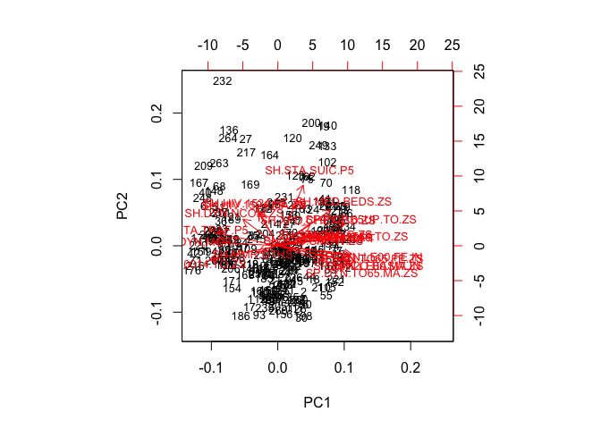

```r
################################################################################
#### Q9-7-Health

library(ggbiplot)
all_data <- q96H_data %>% select(-`Country Name`, -`Country Code`)
all_data %>% prcomp -> q97H_pca
biplot(q97H_pca, cex = 0.8)
```

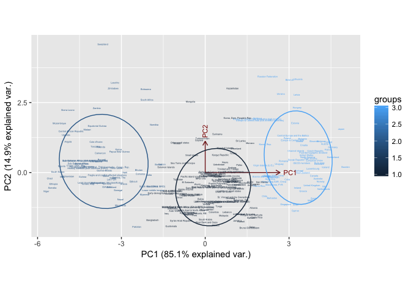

```r
chosen_components <- 1:2
compact_data <- q97H_pca$x[,chosen_components]

compact_data %>% prcomp %>% ggbiplot(obs.scale = 1, var.scale = 1,
                                     groups = q96H_kmeans_data$cluster, ellipse = TRUE, labels = q96H_data$`Country Name`, labels.size = 1)
```

```r
################################################################################
#### Q9-6-Education

q96E_series <- c('SE.ADT.1524.LT.FE.ZS', 'SE.ADT.1524.LT.MA.ZS', 'SE.ADT.LITR.FE.ZS', 'SE.ADT.LITR.MA.ZS',
                 'SE.COM.DURS', 'SE.PRM.NENR', 'SE.XPD.PRIM.PC.ZS', 'SE.XPD.SECO.PC.ZS', 'SE.XPD.TERT.PC.ZS',
                 'SE.XPD.PRIM.ZS', 'SE.XPD.SECO.ZS', 'SE.XPD.TERT.ZS', 'IP.JRN.ARTC.SC', 'GB.XPD.RSDV.GD.ZS',
                 'SE.PRE.ENRL.TC.ZS', 'SE.PRE.ENRR.FE', 'SE.PRE.ENRR.MA', 'SE.PRM.AGES', 'SE.PRM.CMPT.FE.ZS',
                 'SE.PRM.CMPT.MA.ZS')

data %>% select(-X63) %>% filter(`Indicator Code` %in% q96E_series) %>%
  gather(key = 'year', value = 'value', `1960`:`2017`) %>%
  dplyr::group_by(`Indicator Code`) %>% dplyr::mutate(value = normalize(value)) %>%
  ungroup %>% dplyr::group_by(`Country Name`, `Country Code`, `Indicator Code`) %>%
  dplyr::summarise(mean_value = mean(value, na.rm = TRUE)) -> q96E_data

q96E_data %>% spread(key = `Indicator Code`, value = mean_value) -> q96E_data

q96E_data %>% ungroup -> q96E_data

# filling NAs with mean of the column

for (i in 1:ncol(q96E_data)) {
  if ((q96E_data[which(is.na(q96E_data[i])),i] %>% nrow) > 0) {
    q96E_data[which(is.na(q96E_data[i])),i] <- q96E_data[i] %>% na.omit %>% unlist %>% mean
  }
}

q96E_data %>% select(GB.XPD.RSDV.GD.ZS:SE.XPD.TERT.ZS) %>% kmeans(centers = 3) -> q96E_kmeans_data

cbind(
  q96E_data %>% select(`Country Name`, `Country Code`),
  cluster = q96E_kmeans_data$cluster
) -> q96_education_table_data

kable(q96_education_table_data %>% arrange(cluster))
```

| Country Name | Country Code | cluster |
| --- | --- | --- |
| Albania | ALB | 1 |
| Andorra | AND | 1 |
| Antigua and Barbuda | ATG | 1 |
| Argentina | ARG | 1 |
| Armenia | ARM | 1 |
| Aruba | ABW | 1 |
| Australia | AUS | 1 |
| Austria | AUT | 1 |
| Azerbaijan | AZE | 1 |
| Bahamas, The | BHS | 1 |
| Barbados | BRB | 1 |
| Belarus | BLR | 1 |
| Belgium | BEL | 1 |
| Bermuda | BMU | 1 |
| Bolivia | BOL | 1 |
| Bosnia and Herzegovina | BIH | 1 |
| Brazil | BRA | 1 |
| British Virgin Islands | VGB | 1 |
| Brunei Darussalam | BRN | 1 |
| Bulgaria | BGR | 1 |
| Canada | CAN | 1 |
| Caribbean small states | CSS | 1 |
| Cayman Islands | CYM | 1 |
| Central Europe and the Baltics | CEB | 1 |
| Chile | CHL | 1 |
| China | CHN | 1 |
| Colombia | COL | 1 |
| Costa Rica | CRI | 1 |
| Croatia | HRV | 1 |
| Cuba | CUB | 1 |

[output cut: 234 more lines]

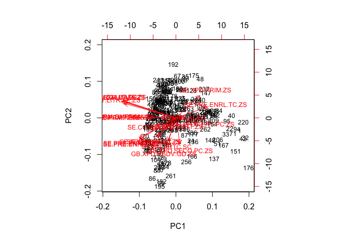

```r
################################################################################
#### Q9-7-Education

all_data <- q96E_data %>% select(-`Country Name`, -`Country Code`)
all_data %>% prcomp -> q97E_pca
biplot(q97E_pca, cex = 0.8)
```

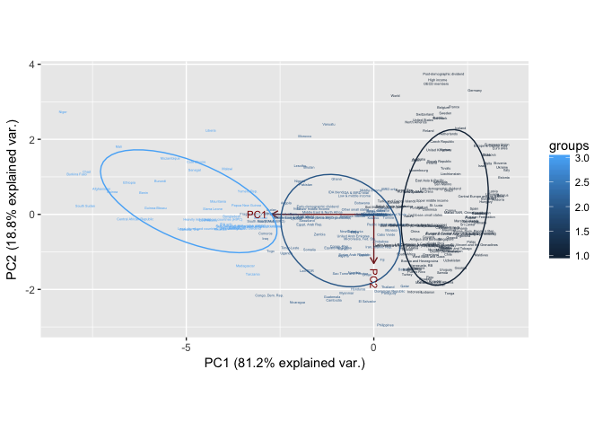

```r
chosen_components <- 1:2
compact_data <- q97E_pca$x[,chosen_components]

compact_data %>% prcomp %>% ggbiplot(obs.scale = 1, var.scale = 1,
                                     groups = q96E_kmeans_data$cluster, ellipse = TRUE, labels = q96E_data$`Country Name`, labels.size = 1)
```

***

۱۰. کشورهای دنیا را بر حسب ۶۰ شاخص اقتصادی، سلامت و آموزش با روش سلسله مراتبی خوشه بندی کرده و دندروگرام آن را رسم نمایید. اگر داده ها بر سه دسته تقسیم شوند ایران در کدام دسته می گنجد؟

> high resoultion plot of dendrogram is provided with iran location marked with a green frame.

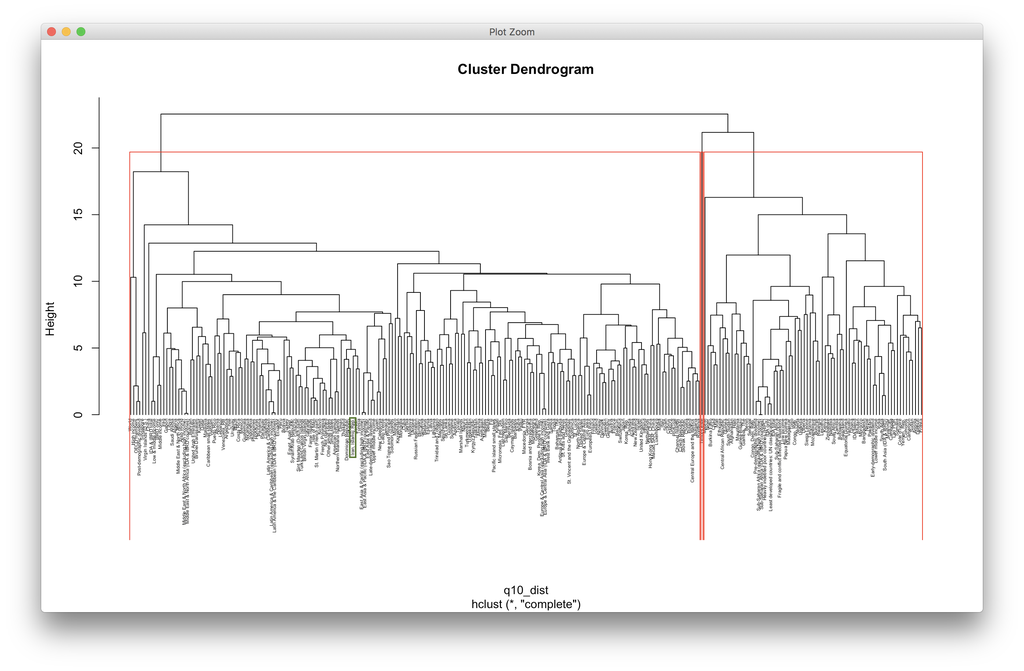

```r
################################################################################
#### Q10

q5_series <- c('NE.EXP.GNFS.ZS', 'NE.IMP.GNFS.ZS', 'FP.CPI.TOTL.ZG', 'NY.GDP.DEFL.KD.ZG',
               'MS.MIL.MPRT.KD', 'MS.MIL.XPRT.KD', 'TX.MNF.TECH.ZS.UN', 'FI.RES.TOTL.CD',
               'GC.TAX.TOTL.GD.ZS', 'GC.TAX.EXPT.ZS', 'BX.KLT.DINV.CD.WD', 'BX.KLT.DINV.WD.GD',
               'NY.GDP.MKTP.KD', 'NY.GDP.MKTP.KD.ZG', 'SI.POV.GAPS', 'SI.POV.LMIC.GP',
               'SI.POV.UMIC.GP', 'BN.CAB.XOKA.GD.ZS', 'NV.AGR.TOTL.ZS', 'SH.XPD.CHEX.GD.ZS',
               'GC.DOD.TOTL.GD.ZS', 'SE.XPD.PRIM.PC.ZS', 'NV.IND.TOTL.ZS')

q10_indexes <- c(q5_series, q96E_series, q96H_series)

data %>% select(-X63) %>% filter(`Indicator Code` %in% q10_indexes) %>%
  gather(key = 'year', value = 'value', `1960`:`2017`) %>%
  dplyr::group_by(`Indicator Code`) %>% dplyr::mutate(value = normalize(value)) %>%
  ungroup %>% dplyr::group_by(`Country Name`, `Country Code`, `Indicator Code`) %>%
  dplyr::summarise(mean_value = mean(value, na.rm = TRUE)) -> q10_data

q10_data %>% spread(key = `Indicator Code`, value = mean_value) %>% ungroup -> q10_data

# filling NAs with mean of the column

for (i in 1:ncol(q10_data)) {
  if ((q10_data[which(is.na(q10_data[i])),i] %>% nrow) > 0) {
    q10_data[which(is.na(q10_data[i])),i] <- q10_data[i] %>% na.omit %>% unlist %>% mean
  }
}

q10_data %>% select(-`Country Code`, -`Country Name`) -> q10_dist_data
rownames(q10_dist_data) <- q10_data$`Country Name`
```

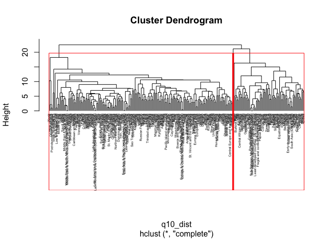

```r
q10_dist <- stats::dist(q10_dist_data,method = "euclidean")


q10_clus <- hclust(q10_dist, method = "complete")

plot(q10_clus, hang = -1, cex = 0.4)
rect.hclust(q10_clus, 3)
```

۱۱. سه یافته جالب از داده ها استخراج کنید.

> 1. iran hsa no hiv prevention program in comparison to rest of the world :(
> 2. economics of germany and japan overtime after world war II; the’ve recovered pretty fast!
> 3. economics vs child per woman in USA. they have nagative correlation!
> 4. terrific impact of 2008 economical crisis on stocks market in USA
> 5. number of iranian journal articles is mindblowing in comparison to rest of the world!

```r
################################################################################
#### Q11


# iran hsa no hiv prevention program in comparison to rest of the world :(
compare_iran_with_others('SH.HIV.1524.FE.ZS', 'Prevalence of HIV, female (% ages 15-24)')
```

[interactive chart not shown]

```r
compare_iran_with_others('SH.HIV.1524.MA.ZS', 'Prevalence of HIV, male (% ages 15-24)')
```

[interactive chart not shown]

```r
# economics of germany and japan overtime after world war II
compare_country_with_others <- function (indicator_code, indicator_name, country_code) {
  data %>% filter(`Indicator Code` == indicator_code) %>%
    gather(key = 'year', value = 'lexp', `1960`:`2016`) %>%
    select(`Country Name`, `Country Code`, year, lexp) %>% .[complete.cases(.),] -> all_country_data


  iran_data <- all_country_data %>% filter(`Country Code` == country_code)

  hcboxplot(x = all_country_data$lexp, var = all_country_data$year, outliers = FALSE) %>% hc_chart(type = "column") %>%
    hc_add_series(type = 'line', iran_data, color = 'red', hcaes(x = year, y = lexp)) %>%
    hc_yAxis(title = list(text = indicator_name)) %>%
    hc_xAxis(title = list(text = 'Year'))
}



compare_country_with_others('NY.GDP.PCAP.CD', 'GDP per capita (current US$)', 'JPN')
```

[interactive chart not shown]

```r
compare_country_with_others('NY.GDP.PCAP.CD', 'GDP per capita (current US$)', 'DEU')
```

[interactive chart not shown]

```r
# economics vs child per woman in USA

data %>% filter(`Country Code` == 'USA') %>% filter(`Indicator Code` %in% c('NY.GDP.PCAP.CD', 'SP.DYN.TFRT.IN')) %>%
  gather(key = 'year', value = 'value', `1960`:`2016`) %>% select(-`2017`, -X63) %>%
  select(`Indicator Code`, year, value) %>% spread(key = `Indicator Code`, value = value) %>% select(-year) -> q11_3_data

cor.test(q11_3_data$NY.GDP.PCAP.CD, q11_3_data$SP.DYN.TFRT.IN) %>% print
```

```
##
##  Pearson's product-moment correlation
##
## data:  q11_3_data$NY.GDP.PCAP.CD and q11_3_data$SP.DYN.TFRT.IN
## t = -3.7842, df = 55, p-value = 0.0003829
## alternative hypothesis: true correlation is not equal to 0
## 95 percent confidence interval:
##  -0.6393571 -0.2199951
## sample estimates:
##        cor
## -0.4545087
```

```r
cor.test(q11_3_data$NY.GDP.PCAP.CD, q11_3_data$SP.DYN.TFRT.IN, method = 'spearm') %>% print
```

```
##
##  Spearman's rank correlation rho
##
## data:  q11_3_data$NY.GDP.PCAP.CD and q11_3_data$SP.DYN.TFRT.IN
## S = 39648, p-value = 0.03204
## alternative hypothesis: true rho is not equal to 0
## sample estimates:
##        rho
## -0.2849365
```

```r
# impact of 2008 economical crisis on stocks market in USA
compare_country_with_others('NY.GDP.PCAP.CD', 'GDP per capita (current US$)', 'USA')
```

[interactive chart not shown]

```r
compare_country_with_others('NY.GDP.MKTP.KD.ZG', 'GDP growth (annual %)', 'USA')
```

[interactive chart not shown]

```r
compare_country_with_others('CM.MKT.TRAD.CD', 'Stocks traded, total value (current US$)', 'USA')
```

[interactive chart not shown]

```r
# number of iranian journal articles is mindblowing
compare_iran_with_others('IP.JRN.ARTC.SC', 'Scientific and technical journal articles')
```

[interactive chart not shown]